# Light vs Dark: a Website Theme Case Study

Andrey Altukhov

2024-07-21

## Exposition

My name is Andrey, I am a data analyst student and today we will look at a problem given to us by the fictional “Master’s Margarita” indian bookstore chain.

The bookstore is looking to optimize its website design to improve user **engagement** and ultimately increase book **purchases**; it currently has two themes: “Light Theme” and “Dark Theme.”

We are given the task to conduct **A/B testing**, a comparison of both themes, to determine which theme leads to better user engagement and higher conversion rates for book purchases.

The data available is data **collected directly from the bookstore’s website**, which makes it a reliable and safe source, directly appliable for solving our problem.

Our **objective** is to finsih data cleaning and analysis, then give a presentation to the bookstore website manager to present our findings.

### Data Exploration

Now that we set up our case problem and context, let’s take a look at our data. It is formatted as a **single .csv**, which means that I won’t be able to show my JOINs in this case study. As mentioned before, we have this data from a **primary source** and it is reliable, original, current, cited and comprehensive, as we’ll see now. No license issues are involved, since the data is **collected from customers by the company**.

To see the source of the data, click [here](https://statso.io/light-theme-and-dark-theme-case-study/)

The data collected by the bookstore contains user interactions and engagement metrics for both the Light Theme and Dark Theme. The dataset includes the following key features:

- Theme: dark or light
- Click Through Rate: The proportion of the users who click on links or buttons on the website.
- Conversion Rate: The percentage of users who signed up on the platform after visiting for the first time.
- Bounce Rate: The percentage of users who leave the website without further interaction after visiting a single page.
- Scroll Depth: The depth to which users scroll through the website pages.
- Age: The age of the user.
- Location: The location of the user.
- Session Duration: The duration of the user’s session on the website.
- Purchases: Whether the user purchased the book (Yes/No).
- Added_to_Cart: Whether the user added books to the cart (Yes/No).

NB: the data has already been pre cleaned, as it contains no user_id and is completely anonymous.

### Data Storage and Preview

Now that we have our data source and meta data, we’ll download it on our local drive. We can see that is a very small dataset, weighting only 109ko, which makes it perfect for pre visualization in Google Sheets.

However, for training and learning purposes, we will be using another new tool: **MySQL**; this open-source relational database management system is known for it’s popularity, better suitability for smaller datasets and infrastructural ease of use, making it the perfect tool for this type of situation, having small and structured data.

## Data Cleaning

Having both our data and the necessary tool (MySQL) to clean it, We apply what we learned step by step to ensure that we:

- Removed duplicates (code removed for RMarkdown, made creating a new table and using DISTINCT)
- Handle Null Values

```sql
UPDATE dirty_data
SET
    `Click Through Rate` = COALESCE(`Click Through Rate`, 0),
    `Conversion Rate` = COALESCE(`Conversion Rate`, 0),
    `Bounce Rate` = COALESCE(`Bounce Rate`, 0),
    `Scroll_Depth` = COALESCE(`Scroll_Depth`, 0),
    `Age` = COALESCE(`Age`, 0),
    `Location` = COALESCE(`Location`, 'Unknown'),
    `Session_Duration` = COALESCE(`Session_Duration`, 0),
    `Purchases` = CASE COALESCE(`Purchases`, 'no') -- the dirty data attributes yes-no answers as strings, we'll have booleans for functionality
                   WHEN 'yes' THEN 1
                   ELSE 0
                 END,
    `Added_to_Cart` = CASE COALESCE(`Added_to_Cart`, 'no')
                       WHEN 'yes' THEN 1
                       ELSE 0
                     END;
```

- Remove rows with outlier values

```sql
DELETE FROM dirty_data
WHERE
    `Click Through Rate` < 0 OR `Click Through Rate` > 1 OR
    `Conversion Rate` < 0 OR `Conversion Rate` > 1 OR
    `Bounce Rate` < 0 OR `Bounce Rate` > 1 OR
    `Scroll_Depth` < 0 OR
    `Age` < 0 OR
    `Session_Duration` < 0;
```

- Ensure data types are correct

```sql
ALTER TABLE dirty_data
MODIFY COLUMN `Click Through Rate` FLOAT,
MODIFY COLUMN `Conversion Rate` FLOAT,
MODIFY COLUMN `Bounce Rate` FLOAT,
MODIFY COLUMN `Scroll_Depth` INT,
MODIFY COLUMN `Age` INT,
MODIFY COLUMN `Location` VARCHAR(255), -- 255 is a general way of using 255 characters maximum for storage, no space wasted
MODIFY COLUMN `Session_Duration` INT,
MODIFY COLUMN `Purchases` TINYINT(1), -- Changed to boolean (TINYINT), a common way of storing booleans we found online
MODIFY COLUMN `Added_to_Cart` TINYINT(1); -- Changed to boolean (TINYINT);
```

- and finally save our cleaned data (Code hidden so RMarkdown doesn’t panic)

## Data Analysis

With our data cleaned, we can start our *A/B test* by providing our hypotheses:

- **Null Hypothesis (H0)**: There is no difference in user engagement between the light and dark themes.
- **Alternative Hypothesis (H1)**: There is a difference in user engagement between the light and dark themes.

To test our hypothesis, we will be using **R**, a powerful language for data analysis and visualizations, which will be helpful to understand and explain our data better.

Different statistical tests exist for A/B testing depending on our variables such as shown below:

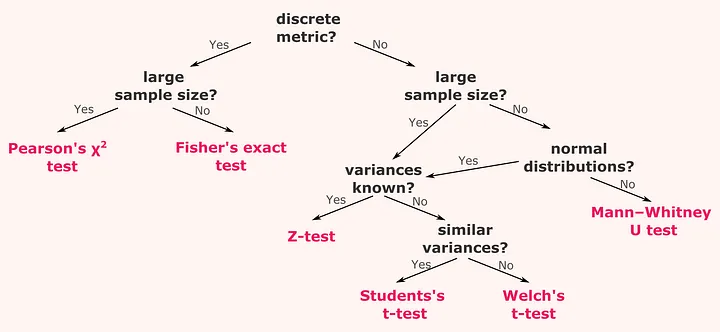

test choice tree

Following our tree, we can use the t-test, specifically the **independent t-test** because we don’t have all the information on the underlying population distribution, or variance, with our two themes being the two independent variables. It presents a margin of error, which is often accepted at 95% accuracy.

A t-test evaluates whether the difference between group means is **statistically significant** by comparing the p-value, the probability of observing the data under the null hypothesis, to a predetermined alpha level,the threshold for significance; where a **p-value less than alpha indicates rejection of the null hypothesis**.

We would be tempted to look at purchases to compare the two themes, however that would be a mistake as the purchase is the last act of the customer, that can be influenced by too may factors other than the website’s theme. the Click Through Rate, Conversion Rate and Bounce Rate are the metrics we are looking for, as they are known to be more affected by the initial response of customers.

```r
# Load necessary libraries
library(dplyr)
```

```r
library(ggplot2)

# Load the dataset
data <- read.csv('C:/Users/altuk/Desktop/Case Studies/cleaned_bookstore_data.csv', fileEncoding = "UTF-8", sep = ';' )

# Filter the data for dark and light themes
dark_theme <- filter(data, Theme == 'Dark Theme')
light_theme <- filter(data, Theme == 'Light Theme')

# Extract CTR, Conversion Rate and Bounce Rate for each theme
dark_ctr <- dark_theme$Click.Through.Rate
light_ctr <- light_theme$Click.Through.Rate

dark_bounce_rate <- dark_theme$Bounce.Rate
light_bounce_rate <- light_theme$Bounce.Rate

dark_conversion_rate <- dark_theme$Conversion.Rate
light_conversion_rate <- light_theme$Conversion.Rate

# Perform an independent two-sample t-test for Click Through Rate
t_test_ctr <- t.test(dark_ctr, light_ctr, alternative = "two.sided", var.equal = FALSE)

# Perform an independent two-sample t-test for Conversion Rate
t_test_conversion <- t.test(dark_conversion_rate, light_conversion_rate, alternative = "two.sided", var.equal = FALSE)

# Perform an independent two-sample t-test for Bounce Rate
t_test_bounce <- t.test(dark_bounce_rate, light_bounce_rate, alternative = "two.sided", var.equal = FALSE)
```

```r
# Interpret the results
alpha <- 0.05  # significance level

print_test_results <- function(test_result, metric_name) {
  cat("\n", toupper(metric_name), "T-Test Results:\n")
  print(test_result)

  if (test_result$p.value < alpha) {
    cat("Reject the null hypothesis (H0) for", metric_name, ". There is a significant difference between the themes.\n")
  } else {
    cat("Fail to reject the null hypothesis (H0) for", metric_name, ". There is no significant difference between the themes.\n")
  }
}

print_test_results(t_test_ctr, "Click Through Rate")
```

```
##
##  CLICK THROUGH RATE T-Test Results:
##
##  Welch Two Sample t-test
##
## data:  dark_ctr and light_ctr
## t = 1.9782, df = 997.13, p-value = 0.04818
## alternative hypothesis: true difference in means is not equal to 0
## 95 percent confidence interval:
##  0.0001391311 0.0346451691
## sample estimates:
## mean of x mean of y
## 0.2645009 0.2471087
##
## Reject the null hypothesis (H0) for Click Through Rate . There is a significant difference between the themes.
```

```r
print_test_results(t_test_conversion, "Conversion Rate")
```

```
##
##  CONVERSION RATE T-Test Results:
##
##  Welch Two Sample t-test
##
## data:  dark_conversion_rate and light_conversion_rate
## t = -0.47485, df = 997.15, p-value = 0.635
## alternative hypothesis: true difference in means is not equal to 0
## 95 percent confidence interval:
##  -0.02144047  0.01308582
## sample estimates:
## mean of x mean of y
## 0.2512820 0.2554593
##
## Fail to reject the null hypothesis (H0) for Conversion Rate . There is no significant difference between the themes.
```

```r
print_test_results(t_test_bounce, "Bounce Rate")
```

```
##
##  BOUNCE RATE T-Test Results:
##
##  Welch Two Sample t-test
##
## data:  dark_bounce_rate and light_bounce_rate
## t = 1.2019, df = 997.41, p-value = 0.2297
## alternative hypothesis: true difference in means is not equal to 0
## 95 percent confidence interval:
##  -0.008275881  0.034435631
## sample estimates:
## mean of x mean of y
## 0.5121146 0.4990348
##
## Fail to reject the null hypothesis (H0) for Bounce Rate . There is no significant difference between the themes.
```

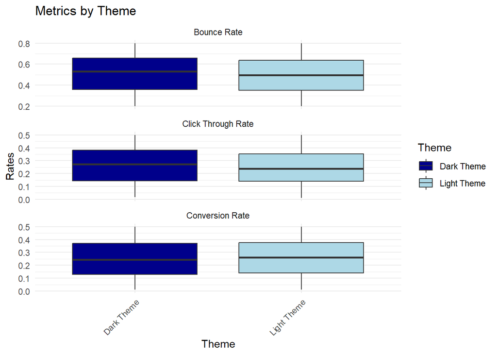

```r
# Prepare data for visualization
combined_data <- rbind(
  data.frame(Theme = "Dark Theme", Metric = "Click Through Rate", Value = dark_ctr),
  data.frame(Theme = "Light Theme", Metric = "Click Through Rate", Value = light_ctr),
  data.frame(Theme = "Dark Theme", Metric = "Conversion Rate", Value = dark_conversion_rate),
  data.frame(Theme = "Light Theme", Metric = "Conversion Rate", Value = light_conversion_rate),
  data.frame(Theme = "Dark Theme", Metric = "Bounce Rate", Value = dark_bounce_rate),
  data.frame(Theme = "Light Theme", Metric = "Bounce Rate", Value = light_bounce_rate)
)

# Create boxplots for visualization
ggplot(combined_data, aes(x = Theme, y = Value, fill = Theme)) +
  geom_boxplot() +
  facet_wrap(~ Metric, scales = "free_y", ncol = 1) +
  labs(title = "Metrics by Theme", x = "Theme", y = "Rates") +
  theme_minimal() +
  scale_fill_manual(values = c("darkblue", "lightblue")) +
  theme(axis.text.x = element_text(angle = 45, hjust = 1))
```

### Results and Recommendations

The results for our t-tests were positive, meaning we rejected the Null Hypothesis H0, for Click Through Rate and negative for both Conversion Rate and Bounce Rate, meaning we failed to reject H0; Therefore, we can be confident that the difference in themes has an effect on the CTR, giving a **slight advantage** to the Dark Theme. However, from the perspective of the Bounce and Conversion Rates, both themes offer a **similar performance**.

The bookstore’s website can therefore adopt the dark theme for having an increased Click Through Rate, which is an important metric of a website and is significant of a more appealing theme for customers. My recommendation would be to implement both themes for the website, based on our failure to reject the two other key metrics, as we cannot unanimously favor the dark theme and confirm that the vast majority of customers are seriously impacted by our choice of theme. This way, we could offer our customers the choice to customize the website to their own preferences, and not miss out on the absence of one theme.